# Short software tutorial on `nonprobsvy` package – replicating results from the Yang et al. (2020)

### 1.3.2 Estimators under PSM I

Naive estimator.

```r
est_naive <- aggregate(cbind(Y_11,Y_12,Y_21,Y_22) ~ 1, sample_B1, mean)
est_naive
```

| Y_11 | Y_12 | Y_21 | Y_22 |
| --- | --- | --- | --- |
| 1.943686 | 7.013049 | 0.7739634 | 0.5969683 |

IPW with variable selection using SCAD penalty (note that this IPW is IPW with calibration constraints on selected variables).

```r
est_b1_ipw_y11 <- nonprob(selection = X_formula,
                          target = ~ Y_11,
                          data = sample_B1,
                          svydesign = sample_A_svy_Y11,
                          control_selection = control_sel_paper,
                          control_inference = control_inf(vars_selection = TRUE))
est_b1_ipw_y12 <- nonprob(selection = X_formula,
                          target = ~ Y_12,
                          data = sample_B1,
                          svydesign = sample_A_svy_Y12,
                          control_selection = control_sel_paper,
                          control_inference = control_inf(vars_selection = TRUE))
est_b1_ipw_y21 <- nonprob(selection = X_formula,
                          target = ~ Y_21,
                          data = sample_B1,
                          svydesign = sample_A_svy_Y21,
                          control_selection = control_sel_paper,
                          control_inference = control_inf(vars_selection = TRUE))
est_b1_ipw_y22 <- nonprob(selection = X_formula,
                          target = ~ Y_22,
                          data = sample_B1,
                          svydesign = sample_A_svy_Y22,
                          control_selection = control_sel_paper,
                          control_inference = control_inf(vars_selection = TRUE))
```

Mass imputation with SCAD penalty.

```r
est_b1_glm_y11 <- nonprob(outcome = as.formula(paste("Y_11", X_formula)),
                          data = sample_B1,
                          svydesign = sample_A_svy_Y11,
                          method_outcome = "glm",
                          family_outcome = "gaussian",
                          control_inference = control_inf(vars_selection = T))
est_b1_glm_y12 <- nonprob(outcome = as.formula(paste("Y_12", X_formula)),
                          data = sample_B1,
                          svydesign = sample_A_svy_Y12,
                          method_outcome = "glm",
                          family_outcome = "gaussian",
                          control_inference = control_inf(vars_selection = T))
est_b1_glm_y21 <- nonprob(outcome = as.formula(paste("Y_21", X_formula)),
                          data = sample_B1,
                          svydesign = sample_A_svy_Y21,
                          method_outcome = "glm",
                          family_outcome = "binomial",
                          control_inference = control_inf(vars_selection = T))
est_b1_glm_y22 <- nonprob(outcome = as.formula(paste("Y_22", X_formula)),
                          data = sample_B1,
                          svydesign = sample_A_svy_Y22,
                          method_outcome = "glm",
                          family_outcome = "binomial",
                          control_inference = control_inf(vars_selection = T))
```

DR with bias minimization with union of variables after selection of variables with SCAD.

```r
est_b1_dr_y11 <- nonprob(outcome = as.formula(paste("Y_11", X_formula)),
                         selection = X_formula,
                         data = sample_B1,
                         svydesign = sample_A_svy_Y11,
                         method_outcome = "glm",
                         family_outcome = "gaussian",
                         control_selection = control_sel_paper_h,
                         control_inference = controls_inf_paper,
                         pop_size = N)
est_b1_dr_y12 <- nonprob(outcome = as.formula(paste("Y_12", X_formula)),
                         selection = X_formula,
                         data = sample_B1,
                         svydesign = sample_A_svy_Y12,
                         method_outcome = "glm",
                         family_outcome = "gaussian",
                         control_selection = control_sel_paper_h,
                         control_inference = controls_inf_paper,
                         pop_size = N)
est_b1_dr_y21 <- nonprob(outcome = as.formula(paste("Y_21", X_formula)),
                         selection = X_formula,
                         data = sample_B1,
                         svydesign = sample_A_svy_Y21,
                         method_outcome = "glm",
                         family_outcome = "binomial",
                         control_selection = control_sel_paper_h,
                         control_inference = controls_inf_paper,
                         pop_size = N)
est_b1_dr_y22 <- nonprob(outcome = as.formula(paste("Y_22", X_formula)),
                         selection = X_formula,
                         data = sample_B1,
                         svydesign = sample_A_svy_Y22,
                         method_outcome = "glm",
                         family_outcome = "binomial",
                         control_selection = control_sel_paper_h,
                         control_inference = controls_inf_paper,
                         pop_size = N)
```

Compare results

```r
results <- rbind(
  cbind(est_b1_ipw_y11$output,est_b1_ipw_y11$confidence_interval),
  cbind(est_b1_ipw_y12$output,est_b1_ipw_y12$confidence_interval),
  cbind(est_b1_ipw_y21$output,est_b1_ipw_y21$confidence_interval),
  cbind(est_b1_ipw_y22$output,est_b1_ipw_y22$confidence_interval),
  cbind(est_b1_glm_y11$output,est_b1_glm_y11$confidence_interval),
  cbind(est_b1_glm_y12$output,est_b1_glm_y12$confidence_interval),
  cbind(est_b1_glm_y21$output,est_b1_glm_y21$confidence_interval),
  cbind(est_b1_glm_y22$output,est_b1_glm_y22$confidence_interval),
  cbind(est_b1_dr_y11$output,est_b1_dr_y11$confidence_interval),
  cbind(est_b1_dr_y12$output,est_b1_dr_y12$confidence_interval),
  cbind(est_b1_dr_y21$output,est_b1_dr_y21$confidence_interval),
  cbind(est_b1_dr_y22$output,est_b1_dr_y22$confidence_interval),
  data.frame(mean = unname(t(est_naive)), SE = NA, lower_bound = NA, upper_bound = NA)
)
rownames(results) <- NULL
results$y <- rep(c("Y_11", "Y_12", "Y_21", "Y_22"), rep = 4)
results$estim <- rep(c("IPW", "MI", "DR", "Naive"), each = 4)
results$estim <- factor(results$estim, c("Naive", "IPW", "MI", "DR"))
results$true  <- rep(c(mean(Y_11), mean(Y_12), mean(Y_21), mean(Y_22)), rep = 6)
results <- results[, c("y", "estim", "mean", "SE", "lower_bound", "upper_bound", "true")]
results <- results[order(results$y, results$estim),]
results
```

|  | y | estim | mean | SE | lower_bound | upper_bound | true |
| --- | --- | --- | --- | --- | --- | --- | --- |
| 13 | Y_11 | Naive | 1.9436859 | NA | NA | NA | 0.9823814 |
| 1 | Y_11 | IPW | 1.0289549 | 0.1860521 | 0.6642995 | 1.3936103 | 0.9823814 |
| 5 | Y_11 | MI | 0.9828881 | 0.1146819 | 0.7581156 | 1.2076606 | 0.9823814 |
| 9 | Y_11 | DR | 0.9947537 | 0.1045595 | 0.7898208 | 1.1996866 | 0.9823814 |
| 14 | Y_12 | Naive | 7.0130489 | NA | NA | NA | 6.8326961 |
| 2 | Y_12 | IPW | 6.3725051 | 0.6135471 | 5.1699748 | 7.5750355 | 6.8326961 |
| 6 | Y_12 | MI | 7.4381079 | 0.2562351 | 6.9358963 | 7.9403195 | 6.8326961 |
| 10 | Y_12 | DR | 6.9389127 | 0.1989222 | 6.5490323 | 7.3287932 | 6.8326961 |
| 15 | Y_21 | Naive | 0.7739634 | NA | NA | NA | 0.6464000 |
| 3 | Y_21 | IPW | 0.6023737 | 0.0603255 | 0.4841378 | 0.7206095 | 0.6464000 |
| 7 | Y_21 | MI | 0.6260115 | 0.0224428 | 0.5820243 | 0.6699986 | 0.6464000 |
| 11 | Y_21 | DR | 0.5936366 | 0.0212716 | 0.5519450 | 0.6353283 | 0.6464000 |
| 16 | Y_22 | Naive | 0.5969683 | NA | NA | NA | 0.6492000 |
| 4 | Y_22 | IPW | 0.6401118 | 0.0982036 | 0.4476363 | 0.8325873 | 0.6492000 |
| 8 | Y_22 | MI | 0.6723439 | 0.0201834 | 0.6327852 | 0.7119025 | 0.6492000 |
| 12 | Y_22 | DR | 0.6723459 | 0.0171599 | 0.6387131 | 0.7059786 | 0.6492000 |

Plot results from one go

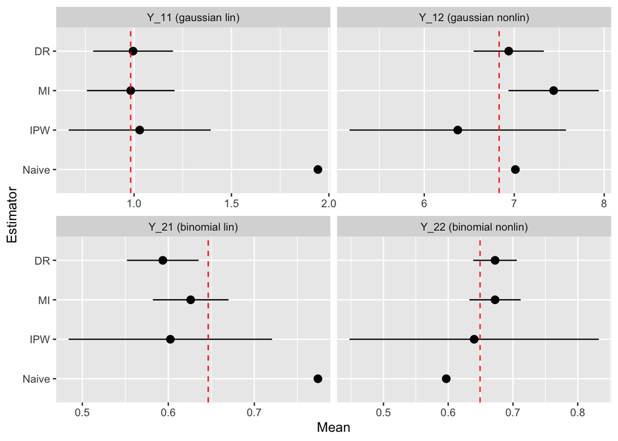

```r
ggplot(data = results, aes(x = estim, y = mean, ymin = lower_bound, ymax = upper_bound)) +
  geom_point() +
  geom_pointrange() +
  geom_hline(aes(yintercept = true), color = "red", linetype = "dashed") +
  facet_wrap(~y, scales = "free_x", labeller = labeller(y = c("Y_11" = "Y_11 (gaussian lin)",
                                                              "Y_12" = "Y_12 (gaussian nonlin)",
                                                              "Y_21" = "Y_21 (binomial lin)",
                                                              "Y_22" = "Y_22 (binomial nonlin)"))) +
  coord_flip() +
  labs(y = "Mean", x = "Estimator")
```

### 1.3.3 Estimators under PSM II

Naive estimator.

```r
est_naive_b2 <- aggregate(cbind(Y_11,Y_12,Y_21,Y_22) ~ 1, sample_B2, mean)
```

IPW with variable selection using SCAD penalty (note that this IPW is IPW with calibration constraints on selected variables).

```r
est_b2_ipw_y11 <- nonprob(selection = X_formula,
                          target = ~ Y_11,
                          data = sample_B2,
                          svydesign = sample_A_svy_Y11,
                          control_selection = control_sel_paper,
                          control_inference = control_inf(vars_selection = TRUE))
est_b2_ipw_y12 <- nonprob(selection = X_formula,
                          target = ~ Y_12,
                          data = sample_B2,
                          svydesign = sample_A_svy_Y12,
                          control_selection = control_sel_paper,
                          control_inference = control_inf(vars_selection = TRUE))
est_b2_ipw_y21 <- nonprob(selection = X_formula,
                          target = ~ Y_21,
                          data = sample_B2,
                          svydesign = sample_A_svy_Y21,
                          control_selection = control_sel_paper,
                          control_inference = control_inf(vars_selection = TRUE))
est_b2_ipw_y22 <- nonprob(selection = X_formula,
                          target = ~ Y_22,
                          data = sample_B2,
                          svydesign = sample_A_svy_Y22,
                          control_selection = control_sel_paper,
                          control_inference = control_inf(vars_selection = TRUE))
```

Mass imputation with SCAD penalty.

```r
est_b2_glm_y11 <- nonprob(outcome = as.formula(paste("Y_11", X_formula)),
                          data = sample_B2,
                          svydesign = sample_A_svy_Y11,
                          method_outcome = "glm",
                          family_outcome = "gaussian",
                          control_inference = control_inf(vars_selection = T))
est_b2_glm_y12 <- nonprob(outcome = as.formula(paste("Y_12", X_formula)),
                          data = sample_B2,
                          svydesign = sample_A_svy_Y12,
                          method_outcome = "glm",
                          family_outcome = "gaussian",
                          control_inference = control_inf(vars_selection = T))
est_b2_glm_y21 <- nonprob(outcome = as.formula(paste("Y_21", X_formula)),
                          data = sample_B2,
                          svydesign = sample_A_svy_Y21,
                          method_outcome = "glm",
                          family_outcome = "binomial",
                          control_inference = control_inf(vars_selection = T))
est_b2_glm_y22 <- nonprob(outcome = as.formula(paste("Y_22", X_formula)),
                          data = sample_B2,
                          svydesign = sample_A_svy_Y22,
                          method_outcome = "glm",
                          family_outcome = "binomial",
                          control_inference = control_inf(vars_selection = T))
```

DR with bias minimization with union of variables after selection of variables with SCAD.

```r
est_b2_dr_y11 <- nonprob(outcome = as.formula(paste("Y_11", X_formula)),
                         selection = X_formula,
                         data = sample_B2,
                         svydesign = sample_A_svy_Y11,
                         method_outcome = "glm",
                         family_outcome = "gaussian",
                         control_selection = control_sel_paper_h,
                         control_inference = controls_inf_paper,
                         pop_size = N)
est_b2_dr_y12 <- nonprob(outcome = as.formula(paste("Y_12", X_formula)),
                         selection = X_formula,
                         data = sample_B2,
                         svydesign = sample_A_svy_Y12,
                         method_outcome = "glm",
                         family_outcome = "gaussian",
                         control_selection = control_sel_paper_h,
                         control_inference = controls_inf_paper,
                         pop_size = N)
est_b2_dr_y21 <- nonprob(outcome = as.formula(paste("Y_21", X_formula)),
                         selection = X_formula,
                         data = sample_B2,
                         svydesign = sample_A_svy_Y21,
                         method_outcome = "glm",
                         family_outcome = "binomial",
                         control_selection = control_sel_paper_h,
                         control_inference = controls_inf_paper,
                         pop_size = N)
est_b2_dr_y22 <- nonprob(outcome = as.formula(paste("Y_22", X_formula)),
                         selection = X_formula,
                         data = sample_B2,
                         svydesign = sample_A_svy_Y22,
                         method_outcome = "glm",
                         family_outcome = "binomial",
                         control_selection = control_sel_paper_h,
                         control_inference = controls_inf_paper,
                         pop_size = N)
```

Compare results

```r
results <- rbind(
  cbind(est_b2_ipw_y11$output,est_b2_ipw_y11$confidence_interval),
  cbind(est_b2_ipw_y12$output,est_b2_ipw_y12$confidence_interval),
  cbind(est_b2_ipw_y21$output,est_b2_ipw_y21$confidence_interval),
  cbind(est_b2_ipw_y22$output,est_b2_ipw_y22$confidence_interval),
  cbind(est_b2_glm_y11$output,est_b2_glm_y11$confidence_interval),
  cbind(est_b2_glm_y12$output,est_b2_glm_y12$confidence_interval),
  cbind(est_b2_glm_y21$output,est_b2_glm_y21$confidence_interval),
  cbind(est_b2_glm_y22$output,est_b2_glm_y22$confidence_interval),
  cbind(est_b2_dr_y11$output, est_b2_dr_y11$confidence_interval),
  cbind(est_b2_dr_y12$output, est_b2_dr_y12$confidence_interval),
  cbind(est_b2_dr_y21$output, est_b2_dr_y21$confidence_interval),
  cbind(est_b2_dr_y22$output, est_b2_dr_y22$confidence_interval),
  data.frame(mean = unname(t(est_naive_b2)), SE = NA, lower_bound = NA, upper_bound = NA)
)
rownames(results) <- NULL
results$y <- rep(c("Y_11", "Y_12", "Y_21", "Y_22"), rep = 4)
results$estim <- rep(c("IPW", "MI", "DR", "Naive"), each = 4)
results$estim <- factor(results$estim, c("Naive", "IPW", "MI", "DR"))
results$true  <- rep(c(mean(Y_11), mean(Y_12), mean(Y_21), mean(Y_22)), rep = 6)
results <- results[, c("y", "estim", "mean", "SE", "lower_bound", "upper_bound", "true")]
results <- results[order(results$y, results$estim),]
results
```

|  | y | estim | mean | SE | lower_bound | upper_bound | true |
| --- | --- | --- | --- | --- | --- | --- | --- |
| 13 | Y_11 | Naive | 0.8690708 | NA | NA | NA | 0.9823814 |
| 1 | Y_11 | IPW | 1.3082471 | 0.3223461 | 0.6764603 | 1.9400339 | 0.9823814 |
| 5 | Y_11 | MI | 0.9852815 | 0.1104110 | 0.7688800 | 1.2016831 | 0.9823814 |
| 9 | Y_11 | DR | 0.9957485 | 0.1090435 | 0.7820272 | 1.2094699 | 0.9823814 |
| 14 | Y_12 | Naive | 5.6923031 | NA | NA | NA | 6.8326961 |
| 2 | Y_12 | IPW | 5.5350593 | 0.3442183 | 4.8604038 | 6.2097148 | 6.8326961 |
| 6 | Y_12 | MI | 5.5198116 | 0.1826572 | 5.1618101 | 5.8778132 | 6.8326961 |
| 10 | Y_12 | DR | 5.4979174 | 0.1162532 | 5.2700652 | 5.7257695 | 6.8326961 |
| 15 | Y_21 | Naive | 0.6121693 | NA | NA | NA | 0.6464000 |
| 3 | Y_21 | IPW | 0.5997402 | 0.0382518 | 0.5247680 | 0.6747123 | 0.6464000 |
| 7 | Y_21 | MI | 0.6440403 | 0.0188337 | 0.6071269 | 0.6809536 | 0.6464000 |
| 11 | Y_21 | DR | 0.6432947 | 0.0171589 | 0.6096639 | 0.6769256 | 0.6464000 |
| 16 | Y_22 | Naive | 0.6402116 | NA | NA | NA | 0.6492000 |
| 4 | Y_22 | IPW | 0.5839018 | 0.0316696 | 0.5218306 | 0.6459730 | 0.6492000 |
| 8 | Y_22 | MI | 0.5998636 | 0.0189954 | 0.5626333 | 0.6370940 | 0.6492000 |
| 12 | Y_22 | DR | 0.6061305 | 0.0163576 | 0.5740702 | 0.6381907 | 0.6492000 |

Plot results from one go

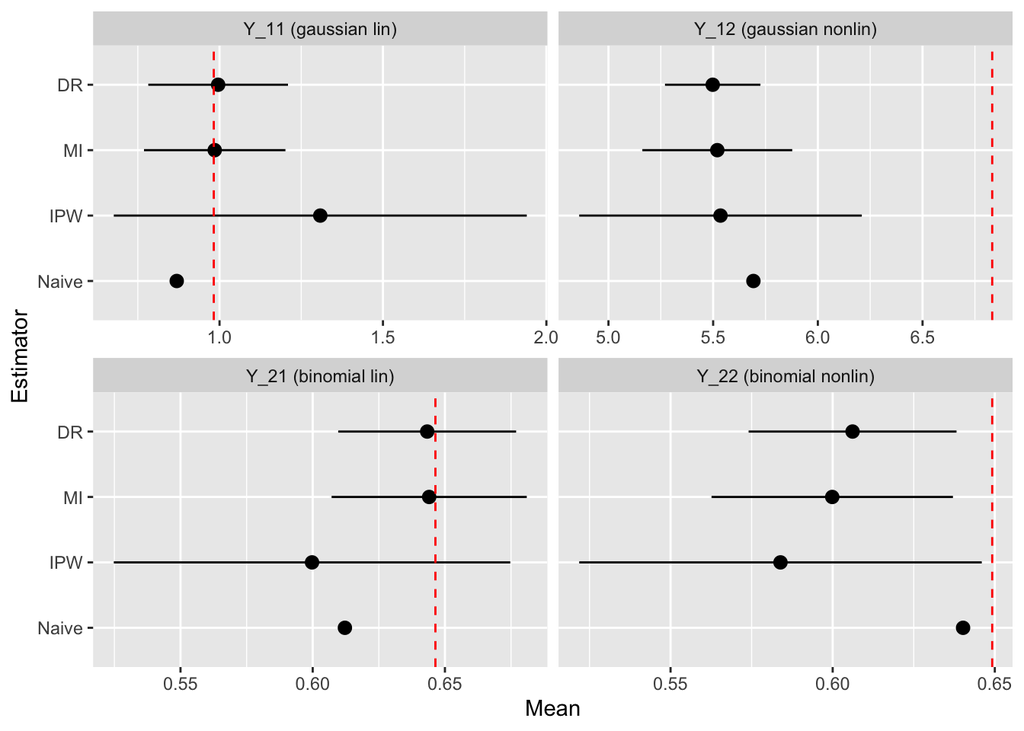

```r
ggplot(data = results, aes(x = estim, y = mean, ymin = lower_bound, ymax = upper_bound)) +
  geom_point() +
  geom_pointrange() +
  geom_hline(aes(yintercept = true), color = "red", linetype = "dashed") +
  facet_wrap(~y, scales = "free_x", labeller = labeller(y = c("Y_11" = "Y_11 (gaussian lin)",
                                                              "Y_12" = "Y_12 (gaussian nonlin)",
                                                              "Y_21" = "Y_21 (binomial lin)",
                                                              "Y_22" = "Y_22 (binomial nonlin)"))) +
  coord_flip() +
  labs(y = "Mean", x = "Estimator")
```

## 1.4 B=500 simulation